# Taller: Análisis de Datos Simulados y Cadenas de Markov Montecarlo

> Integrantes:

> Paula Catalina Hernández Ramírez - 2180048

> Juan Pablo Claro Perez - 2181707

> Daniel David Delgado Cervantes - 2182066

## 1. El enfoque de Bootstrap

Implementando el enfoque del Bootstraping podemos encontrar el valor promedio desconocido $\mu$, tomando las diferentes muestras de una población, esto con el fin de realizar varias réplicas para que por medio de la razón de probabilidad se pueda aproximar su resultado.

```r
# Declaramos los datos otorgados del ejercicio
# X son nuestras muestras de prueba y n es el tamaño de la misma
x <- c(56, 101, 78, 67, 93, 87, 64, 72, 80, 69)
n <- 10

# Ingresamos el intervalo de aceptación del ejercicio
a <- -5
b <- 5

# Promediamos la muestra para obtener nuestro valor desconocido
u <- mean(x)

# Variable contadora la cual nos permite conocer la probabildiad de parametro p
cont_p <- 0

for (i in 1:1000) {
    # Se implementan 1000 iteraciones con el fin de obtener una lectura contundente de los datos realizando el Boostraping
    rep <- sample(x, replace = TRUE)
    rep_medias <- mean(rep)
    theta <- rep_medias - u
    # Se ingresa la condición de aceptación para cada una de las iteraciones
    if (theta > a && theta < b) {
        cont_p <- cont_p + 1
    }
}

p <- cont_p / 1000
p
```

```
## [1] 0.779
```

## 2. Algoritmo Metrocidad Metrópolis

Lo primero a realizar, está en definir la función $f(x)$ pues es a partir de esta que definiremos los valores de nuestra distribución de probabilidad $p(x) = \frac{f(x)}{k}$. En este caso, esta sería nuestra distribución objetivo o distribución $\pi$.

```r
f <- function(x) {
    return(
        ifelse(
            x < 1,
            (exp((x - 1) / 3) + exp((x - 1)**3)),
            (exp(-((x - 1) / 2)) + exp(-((x - 1)**2)))
        )
    )
}
```

De igual manera, tendremos que definir nuestra función de proposición. En este caso, esta está definida como $g(x_t | x_{t-1}) = \mathcal{N}(x_{t-1}, \sigma = 4)$.

```r
prop_f <- function(x, n = 1, sd = 4) {
    return(rnorm(n, x, sd))
}
```

Ya con nuestras funciones definida, podremos como tal realizar la implementación del algoritmo metrópolis con el fin de generar valores de la distribución de probabilidad $p(x) = \frac{f(x)}{k}$.

```r
# Definimos samples como un vector vacío
samples <- c()

# Y definimos nuestro valor inicial x, como no se nos indica el valor usaremos 2
# Por que el 2 se un número muy lindo
x <- 0

# Iniciamos 10000 iteraciones
for (i in c(1:10000)) {
    # Generamos la muestra y (x_t) a partir de nuestra función de proposición.
    y <- prop_f(x)

    # Calculamos la probabilidad de aceptación a
    # Técnicamente hay que aplicar min(1, a),
    # pero si a es mayor que 1, igual será aceptada al ser los
    # valores generados por runif entre 0 y 1
    a <- f(y) / f(x)

    if (runif(1) < a) {
        # En este caso se acepta la muestra. Añadimos y al vector de samples
        samples <- c(samples, y)
        # Y ahora y sería nuestro nuevo x
        x <- y
    } else {
        # En este caso se rechaza la muestra, x no cambia y añadimos x a samples
        samples <- c(samples, x)
    }
}
```

Tras las 10000 iteraciones, podemos ver el resultado de nuestra distribución. Con el fin de verificar la implementación, se presenta la gráfica generada por la función `f`.

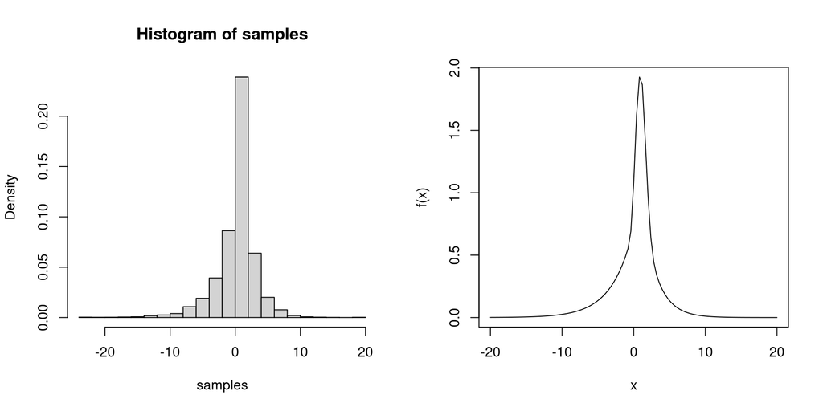

Como podemos ver, tal parece que la implementación del algoritmo de metrópolis efectivamente generó valores los cuales se asemejan a la función objetivo $\pi$.